# DA5020 Logistic Regression

07.2 : Classification with Logistic Regression

Larkin, Yvonne

Fall 2025, October 29, 2025

## 1. Create Project

Data file : [Bank Marketing Dataset](https://s3.us-east-2.amazonaws.com/artificium.us/datasets/bank-term-deposit-marketing-full.csv)  
Relevant information : [UCI Machine Learning Repository : Bank Marketing](https://archive.ics.uci.edu/dataset/222/bank+marketing)

### Bank Client Data Input variables:

1. age (numeric)
2. job : type of job (categorical: “admin.”,“unknown”,“unemployed”,“management”,“housemaid”,“entrepreneur”,“student”, “blue-collar”,“self-employed”,“retired”,“technician”,“services”)
3. marital : marital status (categorical: “married”,“divorced”,“single”; note: “divorced” means divorced or widowed)
4. education (categorical: “unknown”,“secondary”,“primary”,“tertiary”)
5. default: has credit in default? (binary: “yes”,“no”)
6. balance: average yearly balance, in euros (numeric)
7. housing: has housing loan? (binary: “yes”,“no”)
8. loan: has personal loan? (binary: “yes”,“no”)

### related with the last contact of the current campaign:

9. contact: contact communication type (categorical: “unknown”,“telephone”,“cellular”)
10. day: last contact day of the month (numeric)
11. month: last contact month of year (categorical: “jan”, “feb”, “mar”, …, “nov”, “dec”)
12. duration: last contact duration, in seconds (numeric)

### other attributes:

13. campaign: number of contacts performed during this campaign and for this client (numeric, includes last contact)
14. pdays: number of days that passed by after the client was last contacted from a previous campaign (numeric, -1 means client was not previously contacted) 15 - previous: number of contacts performed before this campaign and for this client (numeric) 16 - poutcome: outcome of the previous marketing campaign (categorical: “unknown”,“other”,“failure”,“success”)

### Output variable (desired target):

17. y - has the client subscribed a term deposit? (binary: “yes”,“no”)

Use downloaded data file to create Logistic Regression model to predict variable ‘y’ which indicates whether a bank customer subscribed to a term deposit product.

```r
library(ggplot2) # RStudio suggested https://r4ds.hadley.nz/ when I loaded this; very helpful
library(caret)
```

## 2 Download .CSV to Project and Load from Project

I am loading the file with `stringsAsFactors = TRUE` first in order to have a general understanding of the file. I will overwrite the `df` factors to be how I would like later.

```r
df <- read.csv2("bank-term-deposit-marketing-full.csv",
                header = TRUE,
                # told to do WOE and one-hot encoding
                stringsAsFactors = TRUE)
# confirm load
head(df, 5)
```

|  | age | job | marital | education | default | balance | housing | loan | contact | day | month | duration | campaign | pdays | previous | poutcome | y |
| --- | --- | --- | --- | --- | --- | --- | --- | --- | --- | --- | --- | --- | --- | --- | --- | --- | --- |
| 1 | 58 | management | married | tertiary | no | 2143 | yes | no | unknown | 5 | may | 261 | 1 | -1 | 0 | unknown | no |
| 2 | 44 | technician | single | secondary | no | 29 | yes | no | unknown | 5 | may | 151 | 1 | -1 | 0 | unknown | no |
| 3 | 33 | entrepreneur | married | secondary | no | 2 | yes | yes | unknown | 5 | may | 76 | 1 | -1 | 0 | unknown | no |
| 4 | 47 | blue-collar | married | unknown | no | 1506 | yes | no | unknown | 5 | may | 92 | 1 | -1 | 0 | unknown | no |
| 5 | 33 | unknown | single | unknown | no | 1 | no | no | unknown | 5 | may | 198 | 1 | -1 | 0 | unknown | no |

## 3. Brief Exploratory Data Analysis

```r
str(df)
```

```
## 'data.frame':    45211 obs. of  17 variables:
##  $ age      : int  58 44 33 47 33 35 28 42 58 43 ...
##  $ job      : Factor w/ 12 levels "admin.","blue-collar",..: 5 10 3 2 12 5 5 3 6 10 ...
##  $ marital  : Factor w/ 3 levels "divorced","married",..: 2 3 2 2 3 2 3 1 2 3 ...
##  $ education: Factor w/ 4 levels "primary","secondary",..: 3 2 2 4 4 3 3 3 1 2 ...
##  $ default  : Factor w/ 2 levels "no","yes": 1 1 1 1 1 1 1 2 1 1 ...
##  $ balance  : int  2143 29 2 1506 1 231 447 2 121 593 ...
##  $ housing  : Factor w/ 2 levels "no","yes": 2 2 2 2 1 2 2 2 2 2 ...
##  $ loan     : Factor w/ 2 levels "no","yes": 1 1 2 1 1 1 2 1 1 1 ...
##  $ contact  : Factor w/ 3 levels "cellular","telephone",..: 3 3 3 3 3 3 3 3 3 3 ...
##  $ day      : int  5 5 5 5 5 5 5 5 5 5 ...
##  $ month    : Factor w/ 12 levels "apr","aug","dec",..: 9 9 9 9 9 9 9 9 9 9 ...
##  $ duration : int  261 151 76 92 198 139 217 380 50 55 ...
##  $ campaign : int  1 1 1 1 1 1 1 1 1 1 ...
##  $ pdays    : int  -1 -1 -1 -1 -1 -1 -1 -1 -1 -1 ...
##  $ previous : int  0 0 0 0 0 0 0 0 0 0 ...
##  $ poutcome : Factor w/ 4 levels "failure","other",..: 4 4 4 4 4 4 4 4 4 4 ...
##  $ y        : Factor w/ 2 levels "no","yes": 1 1 1 1 1 1 1 1 1 1 ...
```

```r
summary(df)
```

```
##       age                 job           marital          education
##  Min.   :18.00   blue-collar:9732   divorced: 5207   primary  : 6851
##  1st Qu.:33.00   management :9458   married :27214   secondary:23202
##  Median :39.00   technician :7597   single  :12790   tertiary :13301
##  Mean   :40.94   admin.     :5171                    unknown  : 1857
##  3rd Qu.:48.00   services   :4154
##  Max.   :95.00   retired    :2264
##                  (Other)    :6835
##  default        balance       housing      loan            contact
##  no :44396   Min.   : -8019   no :20081   no :37967   cellular :29285
##  yes:  815   1st Qu.:    72   yes:25130   yes: 7244   telephone: 2906
##              Median :   448                           unknown  :13020
##              Mean   :  1362
##              3rd Qu.:  1428
##              Max.   :102127
##
##       day            month          duration         campaign
##  Min.   : 1.00   may    :13766   Min.   :   0.0   Min.   : 1.000
##  1st Qu.: 8.00   jul    : 6895   1st Qu.: 103.0   1st Qu.: 1.000
##  Median :16.00   aug    : 6247   Median : 180.0   Median : 2.000
##  Mean   :15.81   jun    : 5341   Mean   : 258.2   Mean   : 2.764
##  3rd Qu.:21.00   nov    : 3970   3rd Qu.: 319.0   3rd Qu.: 3.000
##  Max.   :31.00   apr    : 2932   Max.   :4918.0   Max.   :63.000
##                  (Other): 6060
##      pdays          previous           poutcome       y
##  Min.   : -1.0   Min.   :  0.0000   failure: 4901   no :39922
##  1st Qu.: -1.0   1st Qu.:  0.0000   other  : 1840   yes: 5289
##  Median : -1.0   Median :  0.0000   success: 1511
##  Mean   : 40.2   Mean   :  0.5803   unknown:36959
##  3rd Qu.: -1.0   3rd Qu.:  0.0000
##  Max.   :871.0   Max.   :275.0000
##
```

Loaded csv filed with `stringsAsFactors = TRUE` for a more informative `summary(df)` overview. I can see there are no missing values according to the overview, but I will still confirm with `is.na()`. There are many nominal features with a lot of levels, which logistic regression does not handle well.

Currently, only some ‘numeric features’ appear to be “continuous” (though all are integer class), so even if discrete numerically I anticipate some level of detail will be lost with logistic regression, though it may not be that significant as a majority of the features are nominal in nature.

There appear to be extreme outliers with the Max and Mean not being within much farther that the 1st and 3rd Quartile indicate for the feature. General Linera Regreesion can be affected by extreme outliers.

### Missing Values

Borrowing approach from [Module 07.5](http://artificium.us/lessons/03.ml/l-3-440-primer-regression/l-3-440.html) by Professor Schedlbauer. However only `is.na( )` is needed as no string values are present due to `stringsAsFactors = TRUE` in `df`.

```r
#initialize object as false for print
found <- F
unique_list <- list(length = ncol(df))
for(c in 1:ncol(df)){
  missing.Values <- which(is.na(df[,c]))
  num.Missing.Values <- length(missing.Values)
  if(num.Missing.Values > 0){
    print(paste0("Column '", names(df)[c], "' has ", num.Missing.Values, " missing values"))
    found <- T
  }
  print(paste0(length(unique(df[,c])), " unique values in Column '", names(df)[c], "'"))
  unique_list[[c]] <- unique(df[,c])
}
```

```
## [1] "77 unique values in Column 'age'"
## [1] "12 unique values in Column 'job'"
## [1] "3 unique values in Column 'marital'"
## [1] "4 unique values in Column 'education'"
## [1] "2 unique values in Column 'default'"
## [1] "7168 unique values in Column 'balance'"
## [1] "2 unique values in Column 'housing'"
## [1] "2 unique values in Column 'loan'"
## [1] "3 unique values in Column 'contact'"
## [1] "31 unique values in Column 'day'"
## [1] "12 unique values in Column 'month'"
## [1] "1573 unique values in Column 'duration'"
## [1] "48 unique values in Column 'campaign'"
## [1] "559 unique values in Column 'pdays'"
## [1] "41 unique values in Column 'previous'"
## [1] "4 unique values in Column 'poutcome'"
## [1] "2 unique values in Column 'y'"
```

```r
names(unique_list) <- colnames(df)
```

No missing values, which is great. If there were missing values I would likely borrow my approach for the Decision Tree or kNN because neither require a normal distribution and are decent at categorization, though I do think either some features would need to be removed due to scale.

### Rework Factors

Day is the last day of the month a person was contacted and so can be nominal to avoid magnitude. Age has inherent magnitude to it so I will leave as is. Balance, duration, and pdays have large ranges but they have magnitude. I will leave as is to be numeric.

```r
# day
df$day <- ifelse(df$day %in% 1:10, "begin_mo", ifelse(df$day %in% 11:21, "mid-mo", "end_mo"))
df$day <- factor(df$day, levels = c("begin_mo", "mid_mo", "end_mo"))
```

### Split Features For Visualization

[RStudio suggested when ‘ggplot’ Loaded](https://r4ds.hadley.nz/) ; this is actually way more helpful than the ggplot2 Cheatsheet, at least to me for understanding ggplot.

```r
categor_vec <- vector('numeric')
integer_vec <- vector('numeric')
for(c in 1:ncol(df)){
  if(is.factor(df[,c]) == TRUE){
    # I just discovered that R has 'append()' just like python ; for some reason I didn't think it had the same function
    # but I finally tried searching the RHelp since 'factor_vec[length(factor_vec) + 1] <- c' seemed annoying
    categor_vec <- append(categor_vec, c)
  } else {
    integer_vec <- append(integer_vec, c)
  }
  categor_vec
  integer_vec
}
```

### Numeric Visualization : Density Histogram and Box Plot

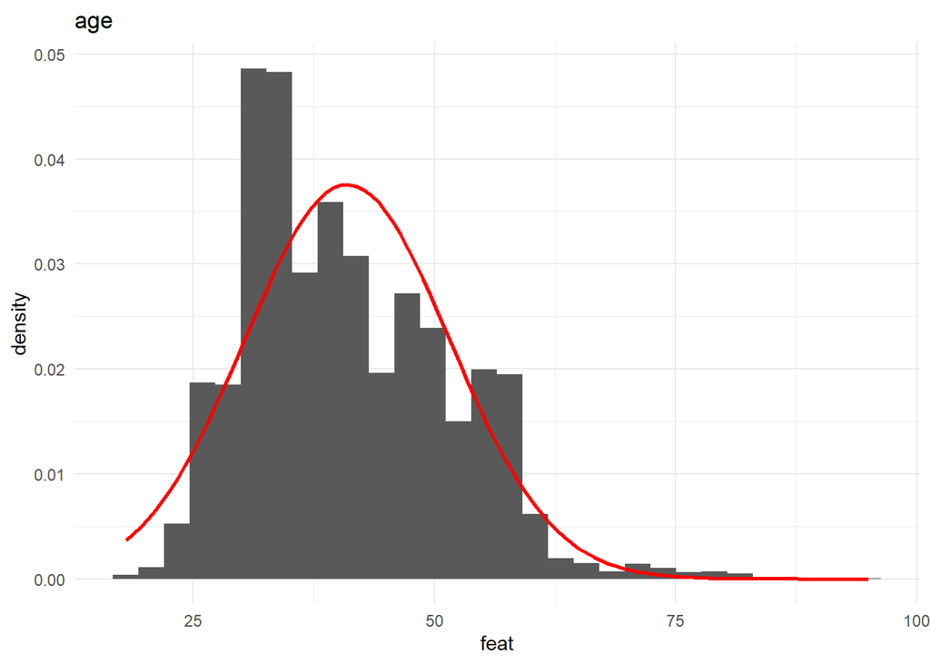

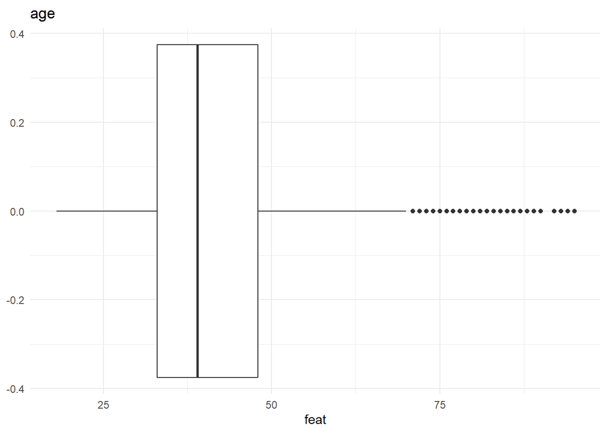

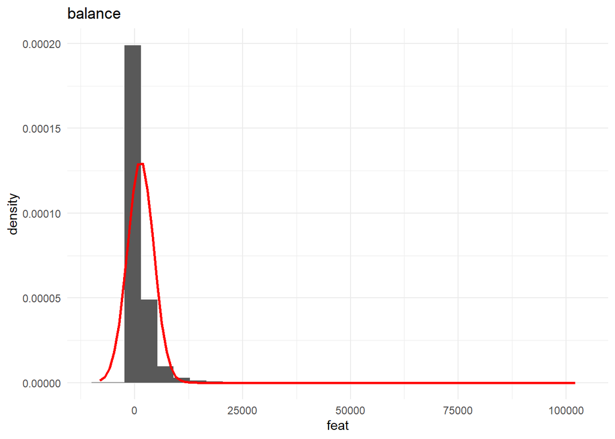

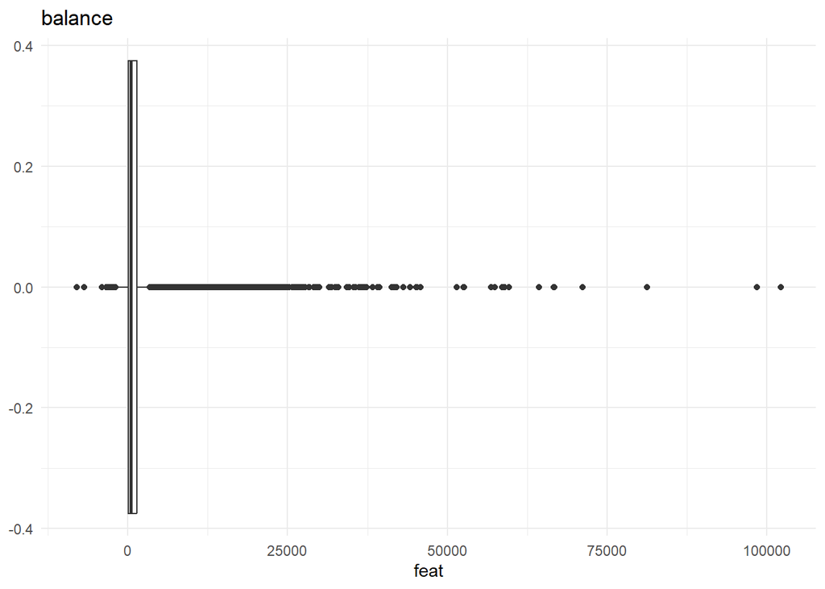

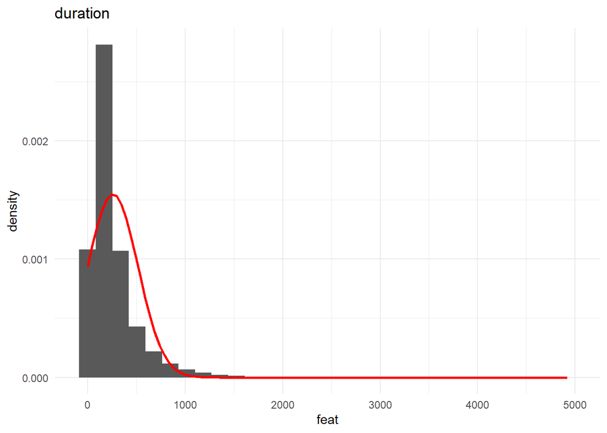

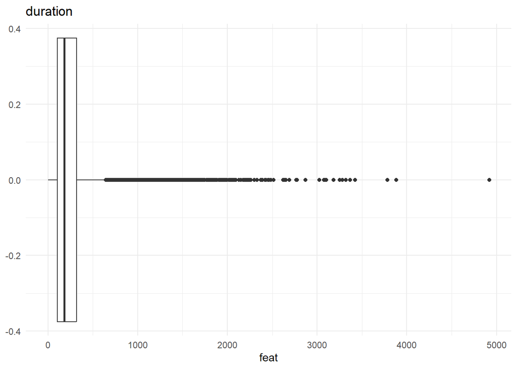

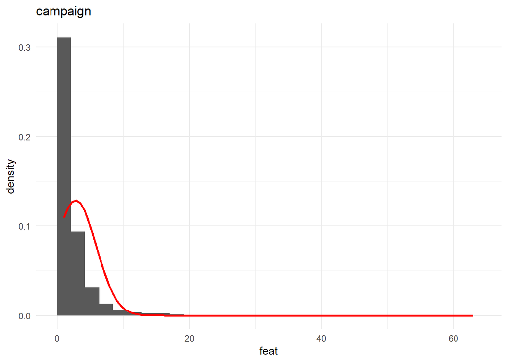

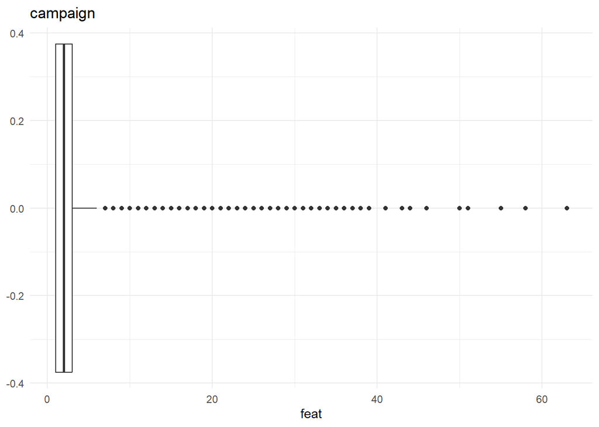

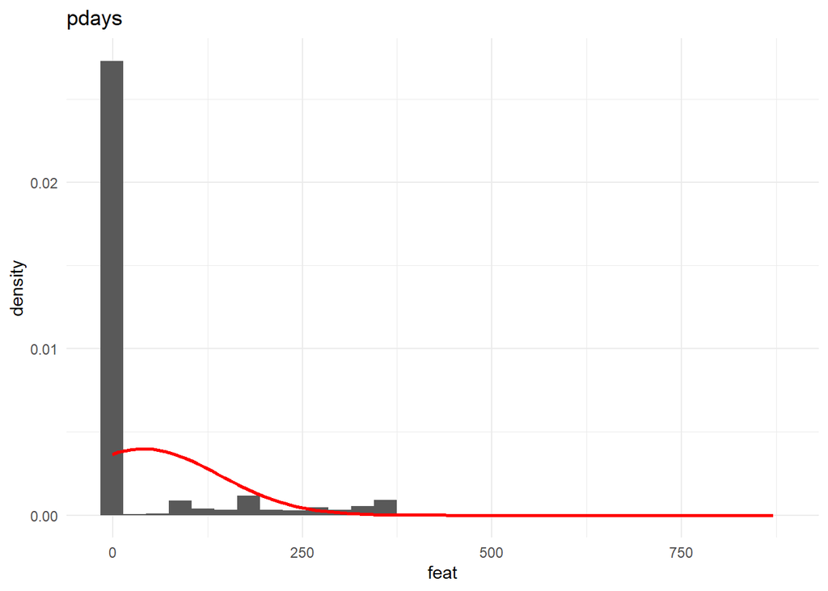

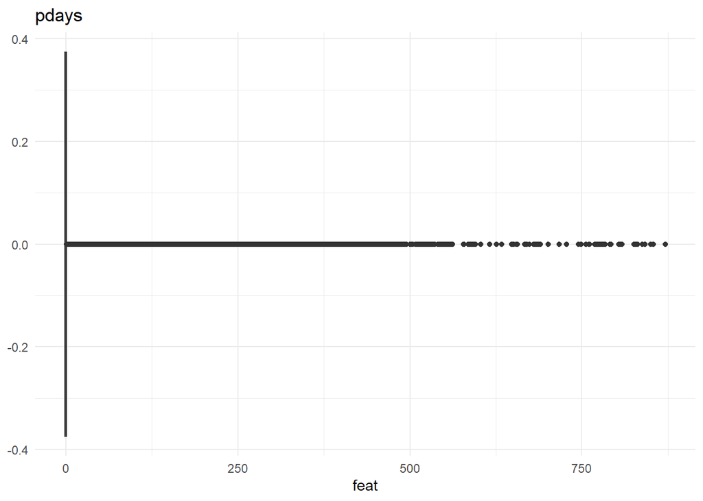

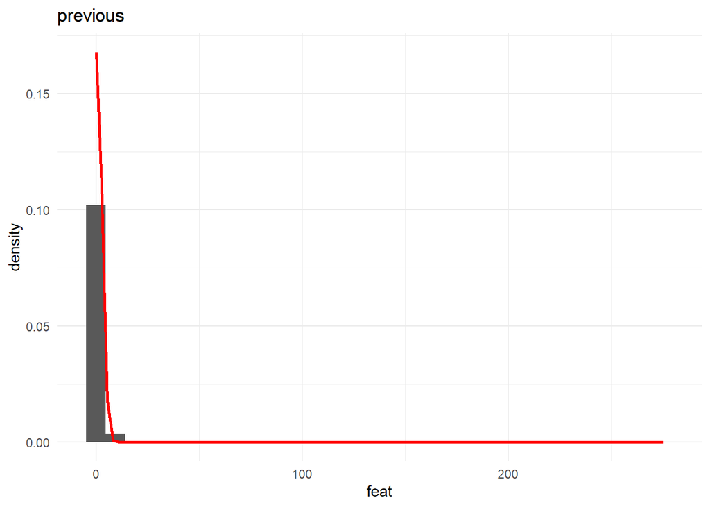

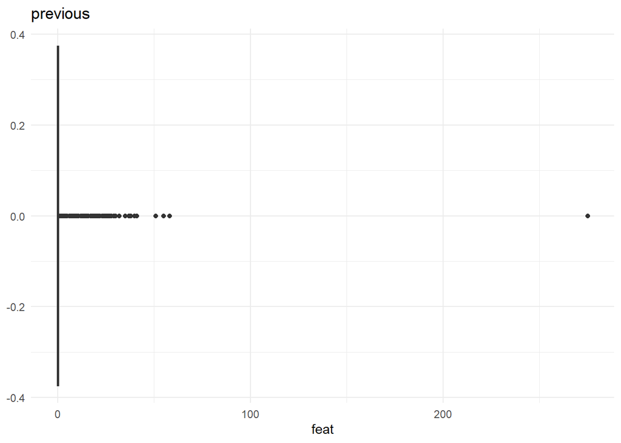

```r
# plot logic from Decision Tree; cite the ggplot2 cheatsheet, since again I always struggle with it
# decided to try for loop intro I saw from Prof Schedlbauer instead of (for i in 1:x)
for (num in integer_vec) {
  feat <- df[[num]]
  # numeric plotting with ggplot2 T.T
  np <- ggplot(df,
              aes(x = feat)) +
    # set bin width to half the sd value of the feature so it is easier to visualize empirical rule
    geom_histogram(aes(y = ..density..),
                   # decided to leave 'na.rm = T' for future use cases ; if NA present
                   linewidth = sd(feat, na.rm = T)/2) +
    stat_function(fun = dnorm,
                  args = list(mean = mean(feat, na.rm = T), sd = sd(feat, na.rm = T)),
                  color = "red",
                  size = 1) +
    ggtitle(names(df[num])) +
    theme_minimal()

  print(np)

  # box plot
  np2 <- ggplot(df,
              aes(x = feat)) +
    geom_boxplot() +
    ggtitle(colnames(df[num])) +
    theme_minimal()

  print(np2)
}
```

Luckily Logistic Regression does not assumes normality and the data does seem to have a distribution that will be transformed by the Weight of Evidence encoding already and so the WoE for logistic regression should be helpful. The ‘days’ numeric seems to have 3 period of binning, but I think treating it as a categorical for day by WoE is probably better than leaving it as numeric.

### Categorical Visualization : Bar Graphs

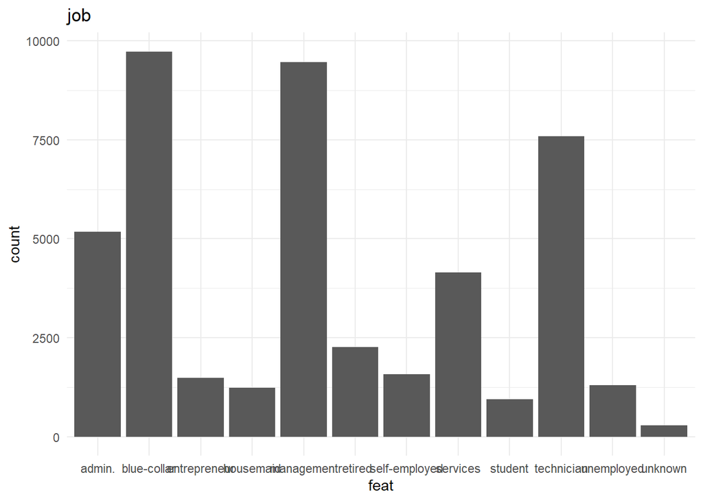

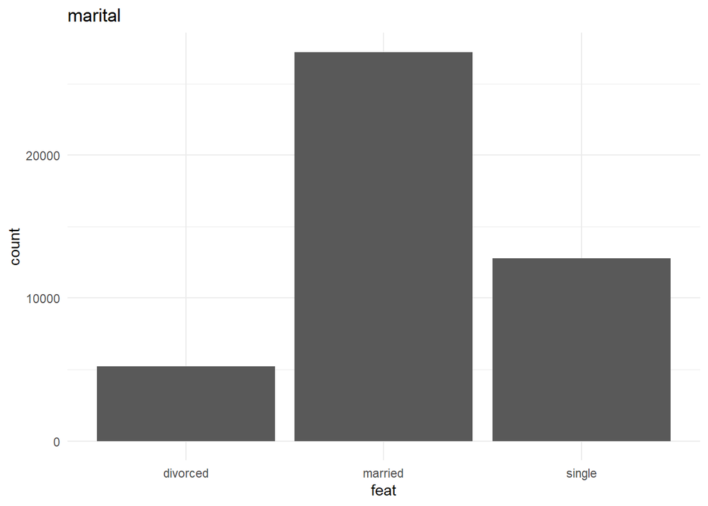

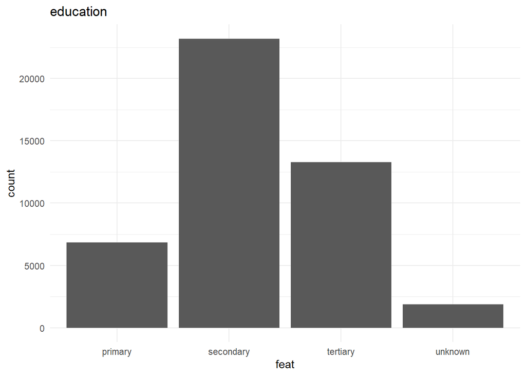

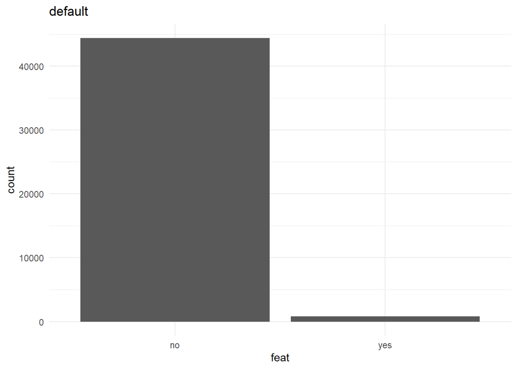

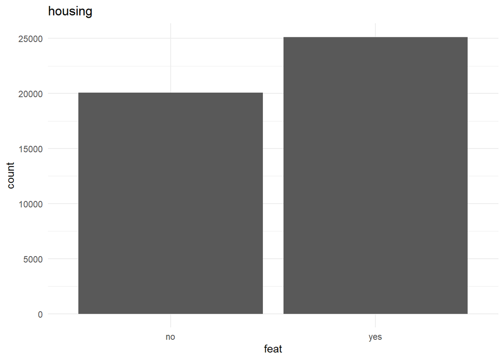

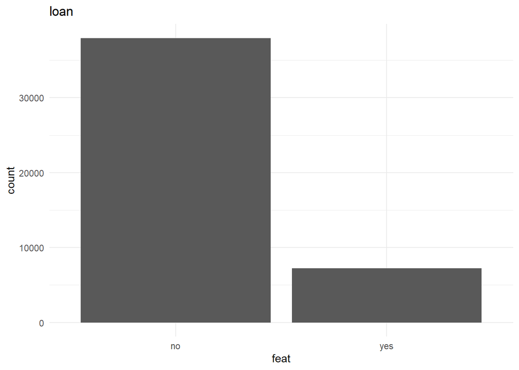

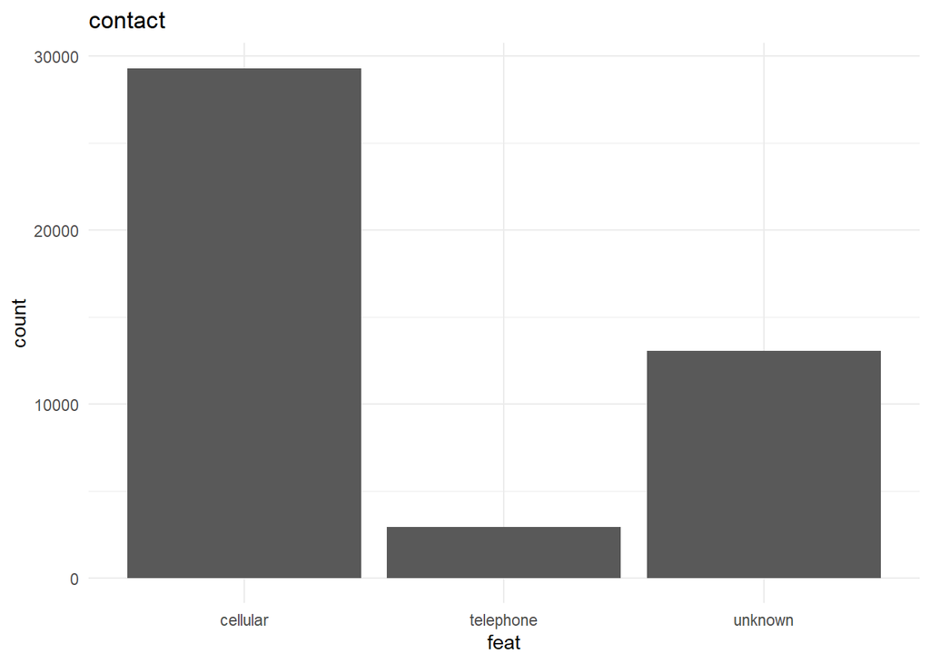

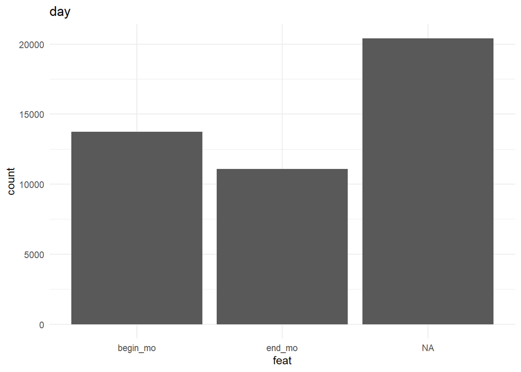

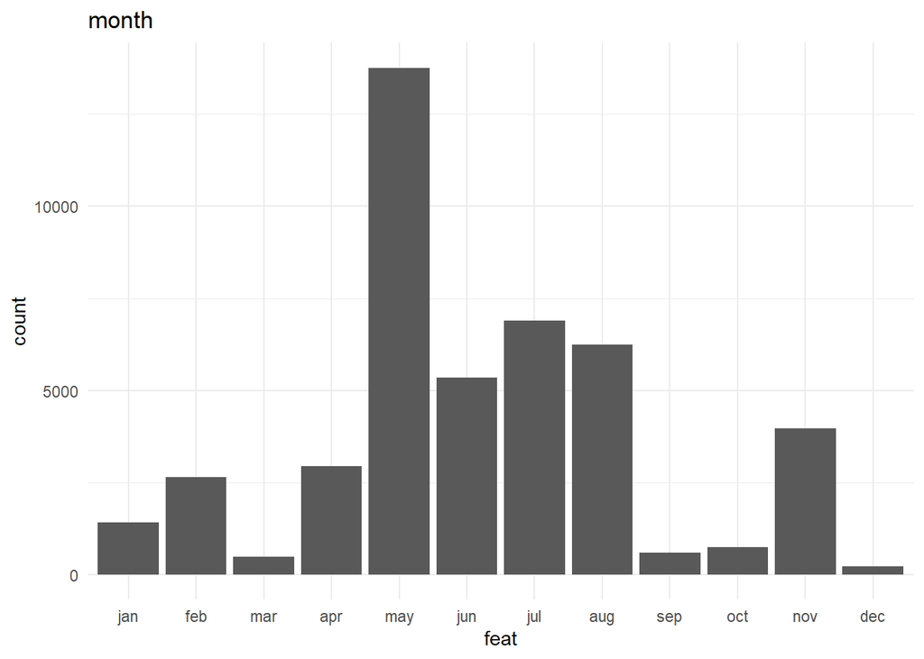

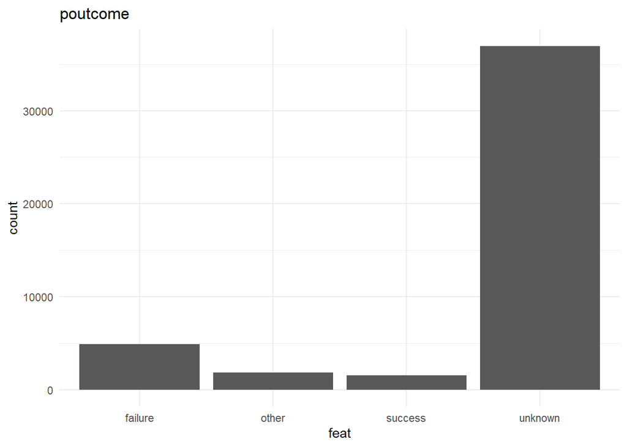

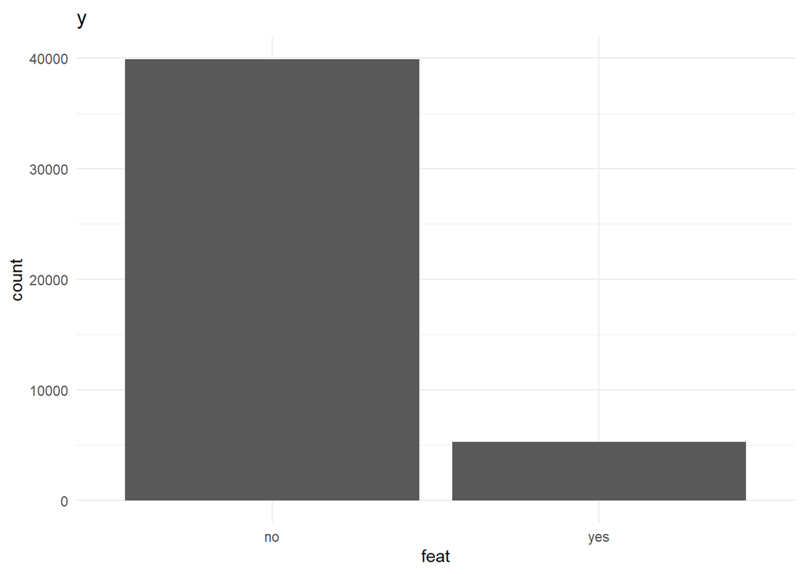

```r
# RHelp on built-ins because I figured there had to be a calendar and alphabet related thing
mon.val <- tolower(month.abb)
df$month  <- factor(df$month, levels = mon.val) # set order for graph to see if any natural breaks seem present

# loop
for(num in categor_vec){
  feat <- df[[num]]
  # categorical plotting with ggplot2 T.T
  cp <- ggplot(df,
              aes(x = feat)) +
    # now looking at frequencies for each category, for discrete values (bins) so bar graph
    geom_bar()+
    ggtitle(colnames(df[num])) +
    theme_minimal()

  print(cp)
}
```

There does seem to be multiple class imbalances in the categorical features. There is a large imbalance for ‘marital’, ‘education’, ‘default’, ‘loan’, ‘contact’, ‘month’, and ‘outcome’. There is a slight imbalance for ‘job’; and relatively none for ‘housing. I anticipate outliers found in ’agd’, ‘duration’, ‘campaign’ ‘pdays’ and ‘previous’ do to the ‘Max.’ values being very far from the ‘Mean’. I’ll have to reference to the UCI page for some context on interpretation of some categories.

## 4. Weight of Evidence Binary Encoding

```r
woe.probability.encoding <- function(feat_col, target){
  # assign binary factor values
  feat_col <- factor(feat_col, levels = c('yes','no'), labels = c(1, 0))

  # counts feature positive
  # feat = 'yes' and y (subscription) = 'yes'
  yes_pos <- length(which(feat_col == 1 & target == 1))
  # feat = 'yes' and y (subscription) = 'no'
  yes_neg <- length(which(feat_col == 1 & target == 0))

  #c counts feature negative
  # feat = 'no' and y(subscription) = 'yes'
  no_pos <- length(which(feat_col == 0 & target == 1))
  # feat = 'no' and y (subscription) = 'no'
  no_neg <- length(which(feat_col == 0 & target == 0))

  # totals for target
  # total target y (subscription) = 'yes'
  sub_yes <- length(which(target == 1))
  # total target y (subscription) = 'no'
  sub_no <- length(which(target == 0))
  #probability + laplace est.

  # probabilities feature positive sub
  P_yes_pos <- (yes_pos + 0.5)/sub_yes
  P_yes_neg <- (yes_neg + 0.5)/sub_no

  # probabilities feature negative
  P_no_pos <- (no_pos + 0.5)/sub_yes
  P_no_neg <- (no_neg + 0.5)/sub_no

  # Weight of Evidence feature leads to successful subscription
  # when feat = yes
  woe.FeatY <- log(P_yes_pos/P_yes_neg)

  # when feat = no
  woe.FeatN <- log(P_no_pos/P_no_neg)

  # assign woe probability as factor values
  woe_col <- ifelse(feat_col == 1, woe.FeatY, woe.FeatN)
  return(woe_col)
}
```

```r
# encode target 'y' manually for function use
df$y <- factor(df$y, levels = c('yes', 'no'), labels = c(1, 0))
```

```r
# number of levels by category
cat_num <- sapply(df[,-which(colnames(df) == 'y')], function(x){
  length(levels(x))})
# index column all features with 2 levels : 'yes','no'
col_binary <- which(cat_num == 2)
```

### new WoE only df

```r
binary_encoded_df <- as.data.frame(lapply(col_binary, function(x){
  feat <- df[,x]
  woe.probability.encoding(feat, df$y)
}))
```

## 4.One-Hot Encoding other Categorical Variables

```r
# index column
col_otherCat <- which(cat_num > 2)
col_otherCat
```

```
##       job   marital education   contact       day     month  poutcome
##         2         3         4         9        10        11        16
```

```r
# create one-hot matrix of desired feature
feature_encode <- function(features){
  n <- levels(features)
  one_hot_n <- length(n) - 1
  # initialize desired columns
  feat_matrix <- matrix(0, nrow = nrow(df), ncol = one_hot_n)
  colnames(feat_matrix) <- n[1:one_hot_n]
  # make df for nesting; but call 'matrix' until final combined df
  new.df <- as.data.frame(feat_matrix)
}
```

```r
# all zero matrices for one-hot encoding so levels - 1
encode_features_matrix <- lapply(col_otherCat, function(x){
  list_name <- feature_encode(df[,x])
})
```

```r
# very nested
encode_and_merge <- function(ma.trix, df){
  matrix_names <- names(ma.trix)
  merge.matrices <- vector(length = nrow(df))
  for(f in matrix_names){
    df_feature <- ma.trix[f]
    feat_levels <- names(ma.trix[[f]])
    for(l in feat_levels){
      index_match <- which(df[,f] == l)
      # index level's column inside feature list
      ma.trix[[f]][[l]][index_match] <- 1
    }
    new_names <- sapply(feat_levels, function(x){ paste0(f,"_", x)})
    colnames(ma.trix[[f]]) <- new_names
    merge.matrices <- cbind(merge.matrices, ma.trix[[f]])
  }
  merge.matrices[-1]
}
```

```r
merged.df <- encode_and_merge(encode_features_matrix, df)
```

## 4. Final Encoded Data Frame

```r
#remaining categories
col_leftover <- df[,-c(col_binary,col_otherCat)]
# combine all into one df
logistic_df <- cbind(col_leftover, merged.df, binary_encoded_df)
# encode target
logistic_df$y <- factor(logistic_df$y, levels = c(1, 0), labels = c("Subscribed", "Not Subscribed"))
```

```r
# reproduce
set.seed(17)
train.index <- createDataPartition(logistic_df$y, p = 0.8, list = FALSE)
# split data sets
training_set <- logistic_df[train.index,]
validation_set <- logistic_df[-train.index,]
```

## 6. General Logistic Regression Model with All Feature

```r
log_model <- glm(y ~.,
                 data = training_set,
                 family = binomial)
colnames(training_set)
```

```
##  [1] "age"                 "balance"             "duration"
##  [4] "campaign"            "pdays"               "previous"
##  [7] "y"                   "job_admin."          "job_blue-collar"
## [10] "job_entrepreneur"    "job_housemaid"       "job_management"
## [13] "job_retired"         "job_self-employed"   "job_services"
## [16] "job_student"         "job_technician"      "job_unemployed"
## [19] "marital_divorced"    "marital_married"     "education_primary"
## [22] "education_secondary" "education_tertiary"  "contact_cellular"
## [25] "contact_telephone"   "day_begin_mo"        "day_mid_mo"
## [28] "month_jan"           "month_feb"           "month_mar"
## [31] "month_apr"           "month_may"           "month_jun"
## [34] "month_jul"           "month_aug"           "month_sep"
## [37] "month_oct"           "month_nov"           "poutcome_failure"
## [40] "poutcome_other"      "poutcome_success"    "default"
## [43] "housing"             "loan"
```

```r
summary(log_model)
```

```
##
## Call:
## glm(formula = y ~ ., family = binomial, data = training_set)
##
## Coefficients: (1 not defined because of singularities)
##                       Estimate Std. Error z value Pr(>|z|)
## (Intercept)          3.773e+00  3.506e-01  10.761  < 2e-16 ***
## age                 -2.431e-04  2.467e-03  -0.099 0.921487
## balance             -1.333e-05  5.605e-06  -2.377 0.017432 *
## duration            -4.275e-03  7.289e-05 -58.643  < 2e-16 ***
## campaign             9.830e-02  1.171e-02   8.394  < 2e-16 ***
## pdays               -1.241e-04  3.393e-04  -0.366 0.714630
## previous            -9.108e-03  6.522e-03  -1.396 0.162609
## job_admin.          -1.921e-01  2.593e-01  -0.741 0.458811
## `job_blue-collar`    1.698e-01  2.589e-01   0.656 0.511834
## job_entrepreneur     1.970e-01  2.818e-01   0.699 0.484482
## job_housemaid        3.697e-01  2.872e-01   1.287 0.197973
## job_management       1.642e-02  2.575e-01   0.064 0.949140
## job_retired         -4.030e-01  2.640e-01  -1.527 0.126882
## `job_self-employed`  6.236e-02  2.742e-01   0.227 0.820075
## job_services         7.971e-02  2.641e-01   0.302 0.762765
## job_student         -6.517e-01  2.717e-01  -2.399 0.016449 *
## job_technician       1.718e-02  2.575e-01   0.067 0.946795
## job_unemployed       4.764e-03  2.752e-01   0.017 0.986188
## marital_divorced     1.131e-02  7.517e-02   0.150 0.880440
## marital_married      2.228e-01  5.167e-02   4.312 1.62e-05 ***
## education_primary    1.812e-01  1.173e-01   1.544 0.122546
## education_secondary  5.260e-03  1.033e-01   0.051 0.959389
## education_tertiary  -2.317e-01  1.085e-01  -2.135 0.032769 *
## contact_cellular    -1.559e+00  8.086e-02 -19.283  < 2e-16 ***
## contact_telephone   -1.398e+00  1.121e-01 -12.466  < 2e-16 ***
## day_begin_mo         1.035e-01  4.783e-02   2.164 0.030478 *
## day_mid_mo                  NA         NA      NA       NA
## month_jan            1.764e+00  2.290e-01   7.704 1.32e-14 ***
## month_feb            7.591e-01  2.072e-01   3.664 0.000249 ***
## month_mar           -1.049e+00  2.268e-01  -4.626 3.73e-06 ***
## month_apr            5.855e-01  2.052e-01   2.853 0.004332 **
## month_may            9.713e-01  2.024e-01   4.798 1.60e-06 ***
## month_jun            1.520e-01  2.087e-01   0.728 0.466394
## month_jul            1.364e+00  2.039e-01   6.689 2.24e-11 ***
## month_aug            1.237e+00  2.021e-01   6.122 9.26e-10 ***
## month_sep           -3.266e-01  2.237e-01  -1.460 0.144289
## month_oct           -4.372e-01  2.181e-01  -2.004 0.045026 *
## month_nov            1.423e+00  2.077e-01   6.852 7.31e-12 ***
## poutcome_failure    -4.901e-02  1.039e-01  -0.472 0.637100
## poutcome_other      -2.737e-01  1.177e-01  -2.326 0.020008 *
## poutcome_success    -2.344e+00  9.565e-02 -24.505  < 2e-16 ***
## default             -5.815e-02  2.727e-01  -0.213 0.831167
## housing             -7.909e-01  5.630e-02 -14.048  < 2e-16 ***
## loan                -5.420e-01  9.461e-02  -5.728 1.01e-08 ***
## ---
## Signif. codes:  0 '***' 0.001 '**' 0.01 '*' 0.05 '.' 0.1 ' ' 1
##
## (Dispersion parameter for binomial family taken to be 1)
##
##     Null deviance: 26108  on 36169  degrees of freedom
## Residual deviance: 17201  on 36127  degrees of freedom
## AIC: 17287
##
## Number of Fisher Scoring iterations: 6
```

```r
mod_sum <- summary(log_model)
significance_vec <- sort(mod_sum$coefficients[,'Pr(>|z|)'], decreasing = TRUE)
head(significance_vec, 5)
```

```
##      job_unemployed education_secondary      job_management      job_technician
##           0.9861882           0.9593887           0.9491396           0.9467954
##                 age
##           0.9214874
```

## 7. Backward Elimination of features by p-value > 0.05

### Remove job related features

```r
col_jobs <- grep("^job_", colnames(training_set))
training_set <- training_set[,-col_jobs]
print(col_jobs)
```

```
##  [1]  8  9 10 11 12 13 14 15 16 17 18
```

```r
colnames(training_set)
```

```
##  [1] "age"                 "balance"             "duration"
##  [4] "campaign"            "pdays"               "previous"
##  [7] "y"                   "marital_divorced"    "marital_married"
## [10] "education_primary"   "education_secondary" "education_tertiary"
## [13] "contact_cellular"    "contact_telephone"   "day_begin_mo"
## [16] "day_mid_mo"          "month_jan"           "month_feb"
## [19] "month_mar"           "month_apr"           "month_may"
## [22] "month_jun"           "month_jul"           "month_aug"
## [25] "month_sep"           "month_oct"           "month_nov"
## [28] "poutcome_failure"    "poutcome_other"      "poutcome_success"
## [31] "default"             "housing"             "loan"
```

```r
log_model <- glm(y ~.,
                 data = training_set,
                 family = binomial)
summary(log_model)
```

```
##
## Call:
## glm(formula = y ~ ., family = binomial, data = training_set)
##
## Coefficients: (1 not defined because of singularities)
##                       Estimate Std. Error z value Pr(>|z|)
## (Intercept)          3.711e+00  2.486e-01  14.927  < 2e-16 ***
## age                 -3.140e-03  2.089e-03  -1.503  0.13284
## balance             -1.364e-05  5.546e-06  -2.459  0.01395 *
## duration            -4.249e-03  7.247e-05 -58.627  < 2e-16 ***
## campaign             1.002e-01  1.170e-02   8.565  < 2e-16 ***
## pdays               -4.725e-05  3.383e-04  -0.140  0.88895
## previous            -9.525e-03  6.581e-03  -1.447  0.14784
## marital_divorced     6.979e-02  7.425e-02   0.940  0.34724
## marital_married      3.078e-01  5.035e-02   6.112 9.84e-10 ***
## education_primary    2.911e-01  1.122e-01   2.595  0.00945 **
## education_secondary  5.293e-02  9.990e-02   0.530  0.59619
## education_tertiary  -1.508e-01  1.015e-01  -1.486  0.13738
## contact_cellular    -1.594e+00  8.078e-02 -19.731  < 2e-16 ***
## contact_telephone   -1.469e+00  1.113e-01 -13.196  < 2e-16 ***
## day_begin_mo         1.081e-01  4.778e-02   2.263  0.02364 *
## day_mid_mo                  NA         NA      NA       NA
## month_jan            1.842e+00  2.296e-01   8.022 1.04e-15 ***
## month_feb            8.244e-01  2.080e-01   3.962 7.42e-05 ***
## month_mar           -1.038e+00  2.277e-01  -4.558 5.16e-06 ***
## month_apr            6.464e-01  2.061e-01   3.136  0.00171 **
## month_may            1.032e+00  2.033e-01   5.075 3.87e-07 ***
## month_jun            2.219e-01  2.096e-01   1.058  0.28983
## month_jul            1.450e+00  2.048e-01   7.080 1.44e-12 ***
## month_aug            1.323e+00  2.028e-01   6.525 6.80e-11 ***
## month_sep           -3.433e-01  2.247e-01  -1.528  0.12662
## month_oct           -4.103e-01  2.190e-01  -1.873  0.06104 .
## month_nov            1.519e+00  2.084e-01   7.292 3.06e-13 ***
## poutcome_failure    -6.888e-02  1.038e-01  -0.664  0.50682
## poutcome_other      -3.047e-01  1.173e-01  -2.597  0.00940 **
## poutcome_success    -2.378e+00  9.539e-02 -24.925  < 2e-16 ***
## default             -1.162e-01  2.727e-01  -0.426  0.67014
## housing             -8.550e-01  5.534e-02 -15.449  < 2e-16 ***
## loan                -5.701e-01  9.428e-02  -6.046 1.48e-09 ***
## ---
## Signif. codes:  0 '***' 0.001 '**' 0.01 '*' 0.05 '.' 0.1 ' ' 1
##
## (Dispersion parameter for binomial family taken to be 1)
##
##     Null deviance: 26108  on 36169  degrees of freedom
## Residual deviance: 17294  on 36138  degrees of freedom
## AIC: 17358
##
## Number of Fisher Scoring iterations: 6
```

```r
mod_sum <- summary(log_model)
significance_vec <- sort(mod_sum$coefficients[,'Pr(>|z|)'], decreasing = TRUE)
head(significance_vec, 5)
```

```
##               pdays             default education_secondary    poutcome_failure
##           0.8889452           0.6701436           0.5961862           0.5068243
##    marital_divorced
##           0.3472384
```

### remove pdays

```r
training_set <- training_set[,-which(colnames(training_set) == 'pdays')]
colnames(training_set)
```

```
##  [1] "age"                 "balance"             "duration"
##  [4] "campaign"            "previous"            "y"
##  [7] "marital_divorced"    "marital_married"     "education_primary"
## [10] "education_secondary" "education_tertiary"  "contact_cellular"
## [13] "contact_telephone"   "day_begin_mo"        "day_mid_mo"
## [16] "month_jan"           "month_feb"           "month_mar"
## [19] "month_apr"           "month_may"           "month_jun"
## [22] "month_jul"           "month_aug"           "month_sep"
## [25] "month_oct"           "month_nov"           "poutcome_failure"
## [28] "poutcome_other"      "poutcome_success"    "default"
## [31] "housing"             "loan"
```

```r
log_model <- glm(y ~.,
                 data = training_set,
                 family = binomial)
summary(log_model)
```

```
##
## Call:
## glm(formula = y ~ ., family = binomial, data = training_set)
##
## Coefficients: (1 not defined because of singularities)
##                       Estimate Std. Error z value Pr(>|z|)
## (Intercept)          3.711e+00  2.485e-01  14.930  < 2e-16 ***
## age                 -3.138e-03  2.089e-03  -1.502 0.133064
## balance             -1.363e-05  5.546e-06  -2.458 0.013985 *
## duration            -4.249e-03  7.247e-05 -58.627  < 2e-16 ***
## campaign             1.002e-01  1.170e-02   8.565  < 2e-16 ***
## previous            -9.505e-03  6.574e-03  -1.446 0.148242
## marital_divorced     6.966e-02  7.425e-02   0.938 0.348122
## marital_married      3.078e-01  5.035e-02   6.112 9.83e-10 ***
## education_primary    2.911e-01  1.122e-01   2.595 0.009457 **
## education_secondary  5.287e-02  9.990e-02   0.529 0.596662
## education_tertiary  -1.506e-01  1.015e-01  -1.484 0.137861
## contact_cellular    -1.594e+00  8.071e-02 -19.755  < 2e-16 ***
## contact_telephone   -1.470e+00  1.113e-01 -13.208  < 2e-16 ***
## day_begin_mo         1.083e-01  4.777e-02   2.267 0.023414 *
## day_mid_mo                  NA         NA      NA       NA
## month_jan            1.842e+00  2.295e-01   8.025 1.02e-15 ***
## month_feb            8.246e-01  2.080e-01   3.965 7.35e-05 ***
## month_mar           -1.038e+00  2.276e-01  -4.559 5.15e-06 ***
## month_apr            6.461e-01  2.061e-01   3.135 0.001719 **
## month_may            1.031e+00  2.032e-01   5.074 3.89e-07 ***
## month_jun            2.218e-01  2.096e-01   1.058 0.289969
## month_jul            1.450e+00  2.047e-01   7.080 1.44e-12 ***
## month_aug            1.324e+00  2.028e-01   6.526 6.75e-11 ***
## month_sep           -3.435e-01  2.247e-01  -1.529 0.126343
## month_oct           -4.101e-01  2.190e-01  -1.873 0.061109 .
## month_nov            1.520e+00  2.082e-01   7.303 2.82e-13 ***
## poutcome_failure    -7.995e-02  6.685e-02  -1.196 0.231729
## poutcome_other      -3.149e-01  9.148e-02  -3.443 0.000576 ***
## poutcome_success    -2.386e+00  7.750e-02 -30.781  < 2e-16 ***
## default             -1.158e-01  2.727e-01  -0.425 0.671056
## housing             -8.543e-01  5.513e-02 -15.497  < 2e-16 ***
## loan                -5.700e-01  9.428e-02  -6.046 1.49e-09 ***
## ---
## Signif. codes:  0 '***' 0.001 '**' 0.01 '*' 0.05 '.' 0.1 ' ' 1
##
## (Dispersion parameter for binomial family taken to be 1)
##
##     Null deviance: 26108  on 36169  degrees of freedom
## Residual deviance: 17294  on 36139  degrees of freedom
## AIC: 17356
##
## Number of Fisher Scoring iterations: 6
```

```r
mod_sum <- summary(log_model)
significance_vec <- sort(mod_sum$coefficients[,'Pr(>|z|)'], decreasing = TRUE)
head(significance_vec, 5)
```

```
##             default education_secondary    marital_divorced           month_jun
##           0.6710555           0.5966622           0.3481218           0.2899686
##    poutcome_failure
##           0.2317286
```

### remove default

```r
training_set <- training_set[,-which(colnames(training_set) == 'default')]
colnames(training_set)
```

```
##  [1] "age"                 "balance"             "duration"
##  [4] "campaign"            "previous"            "y"
##  [7] "marital_divorced"    "marital_married"     "education_primary"
## [10] "education_secondary" "education_tertiary"  "contact_cellular"
## [13] "contact_telephone"   "day_begin_mo"        "day_mid_mo"
## [16] "month_jan"           "month_feb"           "month_mar"
## [19] "month_apr"           "month_may"           "month_jun"
## [22] "month_jul"           "month_aug"           "month_sep"
## [25] "month_oct"           "month_nov"           "poutcome_failure"
## [28] "poutcome_other"      "poutcome_success"    "housing"
## [31] "loan"
```

```r
log_model <- glm(y ~.,
                 data = training_set,
                 family = binomial)
summary(log_model)
```

```
##
## Call:
## glm(formula = y ~ ., family = binomial, data = training_set)
##
## Coefficients: (1 not defined because of singularities)
##                       Estimate Std. Error z value Pr(>|z|)
## (Intercept)          3.711e+00  2.486e-01  14.931  < 2e-16 ***
## age                 -3.138e-03  2.089e-03  -1.502 0.133013
## balance             -1.374e-05  5.539e-06  -2.481 0.013116 *
## duration            -4.249e-03  7.247e-05 -58.632  < 2e-16 ***
## campaign             1.002e-01  1.170e-02   8.568  < 2e-16 ***
## previous            -9.503e-03  6.573e-03  -1.446 0.148255
## marital_divorced     7.013e-02  7.423e-02   0.945 0.344789
## marital_married      3.076e-01  5.035e-02   6.109 1.00e-09 ***
## education_primary    2.910e-01  1.122e-01   2.595 0.009466 **
## education_secondary  5.305e-02  9.989e-02   0.531 0.595404
## education_tertiary  -1.506e-01  1.015e-01  -1.484 0.137762
## contact_cellular    -1.595e+00  8.070e-02 -19.763  < 2e-16 ***
## contact_telephone   -1.471e+00  1.112e-01 -13.221  < 2e-16 ***
## day_begin_mo         1.084e-01  4.777e-02   2.268 0.023312 *
## day_mid_mo                  NA         NA      NA       NA
## month_jan            1.843e+00  2.295e-01   8.027 9.96e-16 ***
## month_feb            8.250e-01  2.080e-01   3.966 7.30e-05 ***
## month_mar           -1.038e+00  2.276e-01  -4.559 5.13e-06 ***
## month_apr            6.463e-01  2.061e-01   3.136 0.001714 **
## month_may            1.032e+00  2.032e-01   5.076 3.86e-07 ***
## month_jun            2.222e-01  2.096e-01   1.060 0.289096
## month_jul            1.451e+00  2.047e-01   7.088 1.36e-12 ***
## month_aug            1.324e+00  2.028e-01   6.530 6.60e-11 ***
## month_sep           -3.434e-01  2.247e-01  -1.528 0.126515
## month_oct           -4.101e-01  2.190e-01  -1.873 0.061105 .
## month_nov            1.522e+00  2.082e-01   7.308 2.71e-13 ***
## poutcome_failure    -8.035e-02  6.685e-02  -1.202 0.229385
## poutcome_other      -3.152e-01  9.149e-02  -3.445 0.000571 ***
## poutcome_success    -2.386e+00  7.748e-02 -30.801  < 2e-16 ***
## housing             -8.542e-01  5.513e-02 -15.495  < 2e-16 ***
## loan                -5.726e-01  9.409e-02  -6.086 1.16e-09 ***
## ---
## Signif. codes:  0 '***' 0.001 '**' 0.01 '*' 0.05 '.' 0.1 ' ' 1
##
## (Dispersion parameter for binomial family taken to be 1)
##
##     Null deviance: 26108  on 36169  degrees of freedom
## Residual deviance: 17295  on 36140  degrees of freedom
## AIC: 17355
##
## Number of Fisher Scoring iterations: 6
```

```r
mod_sum <- summary(log_model)
significance_vec <- sort(mod_sum$coefficients[,'Pr(>|z|)'], decreasing = TRUE)
head(significance_vec, 5)
```

```
## education_secondary    marital_divorced           month_jun    poutcome_failure
##           0.5954039           0.3447887           0.2890956           0.2293854
##            previous
##           0.1482553
```

### remove education related features

```r
col_education <- grep("^education_", colnames(training_set))
training_set <- training_set[,-col_education]
print(col_education)
```

```
## [1]  9 10 11
```

```r
colnames(training_set)
```

```
##  [1] "age"               "balance"           "duration"
##  [4] "campaign"          "previous"          "y"
##  [7] "marital_divorced"  "marital_married"   "contact_cellular"
## [10] "contact_telephone" "day_begin_mo"      "day_mid_mo"
## [13] "month_jan"         "month_feb"         "month_mar"
## [16] "month_apr"         "month_may"         "month_jun"
## [19] "month_jul"         "month_aug"         "month_sep"
## [22] "month_oct"         "month_nov"         "poutcome_failure"
## [25] "poutcome_other"    "poutcome_success"  "housing"
## [28] "loan"
```

```r
log_model <- glm(y ~.,
                 data = training_set,
                 family = binomial)

summary(log_model)
```

```
##
## Call:
## glm(formula = y ~ ., family = binomial, data = training_set)
##
## Coefficients: (1 not defined because of singularities)
##                     Estimate Std. Error z value Pr(>|z|)
## (Intercept)        3.628e+00  2.291e-01  15.836  < 2e-16 ***
## age               -9.093e-04  2.045e-03  -0.445 0.656492
## balance           -1.633e-05  5.515e-06  -2.961 0.003068 **
## duration          -4.239e-03  7.226e-05 -58.662  < 2e-16 ***
## campaign           9.970e-02  1.167e-02   8.541  < 2e-16 ***
## previous          -9.891e-03  6.495e-03  -1.523 0.127796
## marital_divorced   7.865e-02  7.411e-02   1.061 0.288520
## marital_married    3.301e-01  5.023e-02   6.572 4.97e-11 ***
## contact_cellular  -1.623e+00  8.061e-02 -20.138  < 2e-16 ***
## contact_telephone -1.468e+00  1.113e-01 -13.186  < 2e-16 ***
## day_begin_mo       1.047e-01  4.771e-02   2.194 0.028264 *
## day_mid_mo                NA         NA      NA       NA
## month_jan          1.858e+00  2.293e-01   8.104 5.33e-16 ***
## month_feb          8.457e-01  2.077e-01   4.072 4.65e-05 ***
## month_mar         -1.050e+00  2.273e-01  -4.618 3.87e-06 ***
## month_apr          6.731e-01  2.058e-01   3.271 0.001072 **
## month_may          1.065e+00  2.029e-01   5.250 1.52e-07 ***
## month_jun          2.353e-01  2.093e-01   1.124 0.260916
## month_jul          1.481e+00  2.044e-01   7.244 4.34e-13 ***
## month_aug          1.308e+00  2.024e-01   6.462 1.03e-10 ***
## month_sep         -3.292e-01  2.243e-01  -1.468 0.142172
## month_oct         -4.057e-01  2.188e-01  -1.855 0.063650 .
## month_nov          1.526e+00  2.079e-01   7.338 2.17e-13 ***
## poutcome_failure  -8.292e-02  6.672e-02  -1.243 0.213959
## poutcome_other    -3.051e-01  9.140e-02  -3.338 0.000843 ***
## poutcome_success  -2.402e+00  7.735e-02 -31.054  < 2e-16 ***
## housing           -8.662e-01  5.509e-02 -15.722  < 2e-16 ***
## loan              -5.835e-01  9.381e-02  -6.220 4.97e-10 ***
## ---
## Signif. codes:  0 '***' 0.001 '**' 0.01 '*' 0.05 '.' 0.1 ' ' 1
##
## (Dispersion parameter for binomial family taken to be 1)
##
##     Null deviance: 26108  on 36169  degrees of freedom
## Residual deviance: 17339  on 36143  degrees of freedom
## AIC: 17393
##
## Number of Fisher Scoring iterations: 6
```

```r
mod_sum <- summary(log_model)
significance_vec <- sort(mod_sum$coefficients[,'Pr(>|z|)'], decreasing = TRUE)
head(significance_vec, 5)
```

```
##              age marital_divorced        month_jun poutcome_failure
##        0.6564919        0.2885200        0.2609156        0.2139586
##        month_sep
##        0.1421717
```

### remove age

```r
training_set <- training_set[,-which(colnames(training_set) == 'age')]
colnames(training_set)
```

```
##  [1] "balance"           "duration"          "campaign"
##  [4] "previous"          "y"                 "marital_divorced"
##  [7] "marital_married"   "contact_cellular"  "contact_telephone"
## [10] "day_begin_mo"      "day_mid_mo"        "month_jan"
## [13] "month_feb"         "month_mar"         "month_apr"
## [16] "month_may"         "month_jun"         "month_jul"
## [19] "month_aug"         "month_sep"         "month_oct"
## [22] "month_nov"         "poutcome_failure"  "poutcome_other"
## [25] "poutcome_success"  "housing"           "loan"
```

```r
log_model <- glm(y ~.,
                 data = training_set,
                 family = binomial)
summary(log_model)
```

```
##
## Call:
## glm(formula = y ~ ., family = binomial, data = training_set)
##
## Coefficients: (1 not defined because of singularities)
##                     Estimate Std. Error z value Pr(>|z|)
## (Intercept)        3.596e+00  2.175e-01  16.536  < 2e-16 ***
## balance           -1.653e-05  5.494e-06  -3.008 0.002627 **
## duration          -4.239e-03  7.226e-05 -58.672  < 2e-16 ***
## campaign           9.977e-02  1.167e-02   8.548  < 2e-16 ***
## previous          -9.891e-03  6.496e-03  -1.523 0.127842
## marital_divorced   6.546e-02  6.790e-02   0.964 0.334995
## marital_married    3.197e-01  4.448e-02   7.189 6.53e-13 ***
## contact_cellular  -1.622e+00  8.055e-02 -20.137  < 2e-16 ***
## contact_telephone -1.474e+00  1.103e-01 -13.362  < 2e-16 ***
## day_begin_mo       1.050e-01  4.771e-02   2.202 0.027688 *
## day_mid_mo                NA         NA      NA       NA
## month_jan          1.861e+00  2.293e-01   8.115 4.84e-16 ***
## month_feb          8.473e-01  2.077e-01   4.080 4.51e-05 ***
## month_mar         -1.049e+00  2.274e-01  -4.614 3.95e-06 ***
## month_apr          6.757e-01  2.058e-01   3.284 0.001024 **
## month_may          1.068e+00  2.028e-01   5.265 1.41e-07 ***
## month_jun          2.374e-01  2.093e-01   1.134 0.256711
## month_jul          1.483e+00  2.043e-01   7.259 3.90e-13 ***
## month_aug          1.309e+00  2.025e-01   6.468 9.96e-11 ***
## month_sep         -3.291e-01  2.244e-01  -1.467 0.142437
## month_oct         -4.059e-01  2.188e-01  -1.855 0.063582 .
## month_nov          1.528e+00  2.079e-01   7.347 2.02e-13 ***
## poutcome_failure  -8.366e-02  6.670e-02  -1.254 0.209760
## poutcome_other    -3.050e-01  9.139e-02  -3.337 0.000846 ***
## poutcome_success  -2.403e+00  7.730e-02 -31.087  < 2e-16 ***
## housing           -8.700e-01  5.443e-02 -15.982  < 2e-16 ***
## loan              -5.846e-01  9.379e-02  -6.233 4.57e-10 ***
## ---
## Signif. codes:  0 '***' 0.001 '**' 0.01 '*' 0.05 '.' 0.1 ' ' 1
##
## (Dispersion parameter for binomial family taken to be 1)
##
##     Null deviance: 26108  on 36169  degrees of freedom
## Residual deviance: 17339  on 36144  degrees of freedom
## AIC: 17391
##
## Number of Fisher Scoring iterations: 6
```

```r
mod_sum <- summary(log_model)
significance_vec <- sort(mod_sum$coefficients[,'Pr(>|z|)'], decreasing = TRUE)
head(significance_vec, 5)
```

```
## marital_divorced        month_jun poutcome_failure        month_sep
##        0.3349947        0.2567112        0.2097601        0.1424373
##         previous
##        0.1278417
```

### remove maritalrelated features

```r
col_marital <- grep("^marital_", colnames(training_set))
training_set <- training_set[,-col_marital]
print(col_marital)
```

```
## [1] 6 7
```

```r
colnames(training_set)
```

```
##  [1] "balance"           "duration"          "campaign"
##  [4] "previous"          "y"                 "contact_cellular"
##  [7] "contact_telephone" "day_begin_mo"      "day_mid_mo"
## [10] "month_jan"         "month_feb"         "month_mar"
## [13] "month_apr"         "month_may"         "month_jun"
## [16] "month_jul"         "month_aug"         "month_sep"
## [19] "month_oct"         "month_nov"         "poutcome_failure"
## [22] "poutcome_other"    "poutcome_success"  "housing"
## [25] "loan"
```

```r
log_model <- glm(y ~.,
                 data = training_set,
                 family = binomial)
summary(log_model)
```

```
##
## Call:
## glm(formula = y ~ ., family = binomial, data = training_set)
##
## Coefficients: (1 not defined because of singularities)
##                     Estimate Std. Error z value Pr(>|z|)
## (Intercept)        3.798e+00  2.152e-01  17.649  < 2e-16 ***
## balance           -1.519e-05  5.506e-06  -2.759 0.005796 **
## duration          -4.237e-03  7.210e-05 -58.765  < 2e-16 ***
## campaign           1.023e-01  1.173e-02   8.718  < 2e-16 ***
## previous          -9.592e-03  6.557e-03  -1.463 0.143516
## contact_cellular  -1.654e+00  8.044e-02 -20.560  < 2e-16 ***
## contact_telephone -1.467e+00  1.103e-01 -13.299  < 2e-16 ***
## day_begin_mo       1.058e-01  4.764e-02   2.221 0.026357 *
## day_mid_mo                NA         NA      NA       NA
## month_jan          1.831e+00  2.292e-01   7.988 1.37e-15 ***
## month_feb          8.340e-01  2.077e-01   4.015 5.96e-05 ***
## month_mar         -1.063e+00  2.274e-01  -4.675 2.93e-06 ***
## month_apr          6.763e-01  2.058e-01   3.287 0.001013 **
## month_may          1.044e+00  2.028e-01   5.144 2.68e-07 ***
## month_jun          2.287e-01  2.094e-01   1.092 0.274648
## month_jul          1.492e+00  2.044e-01   7.300 2.88e-13 ***
## month_aug          1.341e+00  2.025e-01   6.622 3.53e-11 ***
## month_sep         -3.303e-01  2.244e-01  -1.472 0.141061
## month_oct         -4.073e-01  2.188e-01  -1.861 0.062687 .
## month_nov          1.544e+00  2.080e-01   7.422 1.15e-13 ***
## poutcome_failure  -6.978e-02  6.667e-02  -1.047 0.295210
## poutcome_other    -3.082e-01  9.138e-02  -3.373 0.000744 ***
## poutcome_success  -2.397e+00  7.721e-02 -31.038  < 2e-16 ***
## housing           -8.878e-01  5.430e-02 -16.350  < 2e-16 ***
## loan              -6.016e-01  9.360e-02  -6.427 1.30e-10 ***
## ---
## Signif. codes:  0 '***' 0.001 '**' 0.01 '*' 0.05 '.' 0.1 ' ' 1
##
## (Dispersion parameter for binomial family taken to be 1)
##
##     Null deviance: 26108  on 36169  degrees of freedom
## Residual deviance: 17395  on 36146  degrees of freedom
## AIC: 17443
##
## Number of Fisher Scoring iterations: 6
```

```r
mod_sum <- summary(log_model)
significance_vec <- sort(mod_sum$coefficients[,'Pr(>|z|)'], decreasing = TRUE)
head(significance_vec, 5)
```

```
## poutcome_failure        month_jun         previous        month_sep
##       0.29520952       0.27464832       0.14351579       0.14106071
##        month_oct
##       0.06268718
```

### remove poutcome

```r
col_pout <- grep("^poutcome_", colnames(training_set))
print(col_pout)
```

```
## [1] 21 22 23
```

```r
colnames(training_set)
```

```
##  [1] "balance"           "duration"          "campaign"
##  [4] "previous"          "y"                 "contact_cellular"
##  [7] "contact_telephone" "day_begin_mo"      "day_mid_mo"
## [10] "month_jan"         "month_feb"         "month_mar"
## [13] "month_apr"         "month_may"         "month_jun"
## [16] "month_jul"         "month_aug"         "month_sep"
## [19] "month_oct"         "month_nov"         "poutcome_failure"
## [22] "poutcome_other"    "poutcome_success"  "housing"
## [25] "loan"
```

```r
training_set <- training_set[,-col_pout]

log_model <- glm(y ~ .,
                 data = training_set,
                 family = binomial)
summary(log_model)
```

```
##
## Call:
## glm(formula = y ~ ., family = binomial, data = training_set)
##
## Coefficients: (1 not defined because of singularities)
##                     Estimate Std. Error z value Pr(>|z|)
## (Intercept)        3.467e+00  1.999e-01  17.343  < 2e-16 ***
## balance           -1.609e-05  5.231e-06  -3.077 0.002091 **
## duration          -4.172e-03  7.080e-05 -58.917  < 2e-16 ***
## campaign           1.248e-01  1.180e-02  10.583  < 2e-16 ***
## previous          -8.297e-02  7.961e-03 -10.421  < 2e-16 ***
## contact_cellular  -1.854e+00  7.739e-02 -23.957  < 2e-16 ***
## contact_telephone -1.602e+00  1.069e-01 -14.985  < 2e-16 ***
## day_begin_mo       1.226e-01  4.615e-02   2.657 0.007885 **
## day_mid_mo                NA         NA      NA       NA
## month_jan          2.143e+00  2.138e-01  10.023  < 2e-16 ***
## month_feb          1.094e+00  1.918e-01   5.705 1.16e-08 ***
## month_mar         -7.597e-01  2.112e-01  -3.598 0.000321 ***
## month_apr          1.005e+00  1.900e-01   5.287 1.24e-07 ***
## month_may          1.311e+00  1.871e-01   7.010 2.39e-12 ***
## month_jun          4.371e-01  1.937e-01   2.257 0.023986 *
## month_jul          1.822e+00  1.883e-01   9.675  < 2e-16 ***
## month_aug          1.651e+00  1.867e-01   8.844  < 2e-16 ***
## month_sep         -2.600e-01  2.068e-01  -1.257 0.208627
## month_oct         -2.359e-01  2.018e-01  -1.169 0.242420
## month_nov          1.851e+00  1.927e-01   9.608  < 2e-16 ***
## housing           -9.668e-01  5.263e-02 -18.369  < 2e-16 ***
## loan              -7.530e-01  9.193e-02  -8.190 2.60e-16 ***
## ---
## Signif. codes:  0 '***' 0.001 '**' 0.01 '*' 0.05 '.' 0.1 ' ' 1
##
## (Dispersion parameter for binomial family taken to be 1)
##
##     Null deviance: 26108  on 36169  degrees of freedom
## Residual deviance: 18393  on 36149  degrees of freedom
## AIC: 18435
##
## Number of Fisher Scoring iterations: 6
```

```r
mod_sum <- summary(log_model)
significance_vec <- sort(mod_sum$coefficients[,'Pr(>|z|)'], decreasing = TRUE)
head(significance_vec, 5)
```

```
##    month_oct    month_sep    month_jun day_begin_mo      balance
##  0.242419529  0.208626714  0.023985721  0.007884836  0.002091303
```

### remove month related features

```r
col_month <- grep("^month_", colnames(training_set))
print(col_month)
```

```
##  [1] 10 11 12 13 14 15 16 17 18 19 20
```

```r
colnames(training_set)
```

```
##  [1] "balance"           "duration"          "campaign"
##  [4] "previous"          "y"                 "contact_cellular"
##  [7] "contact_telephone" "day_begin_mo"      "day_mid_mo"
## [10] "month_jan"         "month_feb"         "month_mar"
## [13] "month_apr"         "month_may"         "month_jun"
## [16] "month_jul"         "month_aug"         "month_sep"
## [19] "month_oct"         "month_nov"         "housing"
## [22] "loan"
```

```r
training_set <- training_set[,-col_month]

log_model <- glm(y ~ .,
                 data = training_set,
                 family = binomial)
summary(log_model)
```

```
##
## Call:
## glm(formula = y ~ ., family = binomial, data = training_set)
##
## Coefficients: (1 not defined because of singularities)
##                     Estimate Std. Error z value Pr(>|z|)
## (Intercept)        4.277e+00  7.215e-02  59.272  < 2e-16 ***
## balance           -2.183e-05  4.854e-06  -4.497  6.9e-06 ***
## duration          -3.991e-03  6.831e-05 -58.424  < 2e-16 ***
## campaign           1.617e-01  1.152e-02  14.043  < 2e-16 ***
## previous          -1.157e-01  7.521e-03 -15.382  < 2e-16 ***
## contact_cellular  -1.387e+00  6.153e-02 -22.536  < 2e-16 ***
## contact_telephone -1.278e+00  9.264e-02 -13.796  < 2e-16 ***
## day_begin_mo      -1.114e-01  4.038e-02  -2.759  0.00579 **
## day_mid_mo                NA         NA      NA       NA
## housing           -1.097e+00  4.574e-02 -23.985  < 2e-16 ***
## loan              -1.056e+00  8.916e-02 -11.840  < 2e-16 ***
## ---
## Signif. codes:  0 '***' 0.001 '**' 0.01 '*' 0.05 '.' 0.1 ' ' 1
##
## (Dispersion parameter for binomial family taken to be 1)
##
##     Null deviance: 26108  on 36169  degrees of freedom
## Residual deviance: 19549  on 36160  degrees of freedom
## AIC: 19569
##
## Number of Fisher Scoring iterations: 6
```

```r
mod_sum <- summary(log_model)
significance_vec <- sort(mod_sum$coefficients[,'Pr(>|z|)'], decreasing = TRUE)
head(significance_vec, 5)
```

```
##      day_begin_mo           balance              loan contact_telephone
##      5.792948e-03      6.896095e-06      2.423831e-32      2.692186e-43
##          campaign
##      8.469470e-45
```

## 7. Final Model

```r
colnames(training_set)
```

```
##  [1] "balance"           "duration"          "campaign"
##  [4] "previous"          "y"                 "contact_cellular"
##  [7] "contact_telephone" "day_begin_mo"      "day_mid_mo"
## [10] "housing"           "loan"
```

```r
eq_variables <- colnames(training_set)
eq_slopes <- sapply(eq_variables, function(x){
  if(x %in% rownames(mod_sum$coefficients)){
   mod_sum$coefficients[x, 'Estimate']
  }
})
equation <- glm(y ~ balance + duration + campaign + previous + contact_cellular + contact_telephone + day_begin_mo + day_mid_mo + housing + loan,
                data = training_set,
                family = binomial)
equation
```

```
##
## Call:  glm(formula = y ~ balance + duration + campaign + previous +
##     contact_cellular + contact_telephone + day_begin_mo + day_mid_mo +
##     housing + loan, family = binomial, data = training_set)
##
## Coefficients:
##       (Intercept)            balance           duration           campaign
##         4.277e+00         -2.183e-05         -3.991e-03          1.617e-01
##          previous   contact_cellular  contact_telephone       day_begin_mo
##        -1.157e-01         -1.387e+00         -1.278e+00         -1.114e-01
##        day_mid_mo            housing               loan
##                NA         -1.097e+00         -1.056e+00
##
## Degrees of Freedom: 36169 Total (i.e. Null);  36160 Residual
## Null Deviance:       26110
## Residual Deviance: 19550     AIC: 19570
```

$$Probability("Subscribed") =
\frac{1}{1 + e^{-( \alpha + \beta1 \cdot \text{balance} + \beta_2 \cdot
\text{duration} + \beta_3 \cdot \text{campaign} + \beta_4 \cdot
\text{previous} + \beta_5 \cdot \text{contact_cellular} + \beta_6 \cdot
\text{contact_telephone} + \beta_7 \cdot \text{day_begin_mo} + \beta_8
\cdot \text{day_mid_mo} + \beta_9 \cdot \text{housing} + \beta_10 \cdot
\text{loan})}}$$
Where $\alpha$ = Intercept of Model, and $\beta$ corresponds to the feature Coefficients

## 8. Evaluate Logistic Regression Model

```r
pred_probability <- predict(equation,
                       newdata = validation_set[, -which(colnames(validation_set) == 'y')],
                       type = 'response')

pred_y <- ifelse(pred_probability > 0.5, 1, 0)
pred_y <- factor(pred_y, levels = c(1, 0), labels = c("Subscribed", "Not Subscribed"))
accuracy_glm <- confusionMatrix(pred_y, validation_set$y)
accuracy_glm
```

```
## Confusion Matrix and Statistics
##
##                 Reference
## Prediction       Subscribed Not Subscribed
##   Subscribed            840           7822
##   Not Subscribed        217            162
##
##                Accuracy : 0.1108
##                  95% CI : (0.1044, 0.1175)
##     No Information Rate : 0.8831
##     P-Value [Acc > NIR] : 1
##
##                   Kappa : -0.0449
##
##  Mcnemar's Test P-Value : <2e-16
##
##             Sensitivity : 0.79470
##             Specificity : 0.02029
##          Pos Pred Value : 0.09698
##          Neg Pred Value : 0.42744
##              Prevalence : 0.11691
##          Detection Rate : 0.09291
##    Detection Prevalence : 0.95808
##       Balanced Accuracy : 0.40750
##
##        'Positive' Class : Subscribed
##
```

```r
overall_ac <- round(accuracy_glm$overall['Accuracy'], 3) *100
kappa_mod <- round(accuracy_glm$overall['Kappa'], 3)
nir_pred <- round(accuracy_glm$overall['AccuracyNull'],3) * 100
TPos <- round(accuracy_glm$byClass['Sensitivity'], 3) * 100
TNeg <- round(accuracy_glm$byClass['Specificity'], 3) * 100
```

## 9. Commentary

**Overall model accuracy is 11.1%** with a kappa around -0.045, this is not a good fit for the data, by the significant under-performance compared to the No Information Rate prediction of 88.3%. The overall **True Positive prediction is approximately 79.5%** which isn’t bad, but the **True Negative is approximately 2%** and that is significantly unreliable to predict the Subscription rate. This is likely attributed to the huge class imbalance that was indicated by the bar graphs previously. And with the model heavily proportioned for positive “Subscribed” members, it could be causing the bias towards “False Positives”.

The Decision Tree had a better performance overall. However, the current glm() has one-hot encoding used for all categorical variables that are not binary. If we could even just apply weight of evidence for those features to reduce the n-dimensional problem with glm(), I think the model could perform better overall. Both the Decision Tree and this General Logistic Regression model, lose date in the process of binning, so there are on equal footing. I would say that if this data set was encoded differently it might be okay to use, but due to it being a regression model that assume linearity of data correlation, it isn’t best suited for the nominal features and so I’d go with the Decision Tree.